# Identification of Marker Genes Across Multiple Datasets

Elif Ayse Ozcan

24 03 2021

# Abstract

The increasing amount of RNA-seq data from independent studies are combined to assess the studies’ statistical significance of medical questions. Therefore, meta-analysis, in which relevant but independent studies are gathered to form one large data, has become a highly popular method for analysis in medical reports. In this protocol, meta-analysis is used to assess the transcriptional differences in a subset of CD8+ T cells, particularly exhausted CD8+ T cells known to lose the proper cytotoxic T cell functioning in long-term exposure to viral infection occurs. Four datasets examining exhaustion in CD8+ T cells are collected and combined to determine the transcriptome of the exhaustion in a precise and accurate manner.

# Introduction

CD8+ T cells, also known as cytotoxic T cells, maintain adaptive immunity via killing intracellular pathogens and tumors. In the effector state in which T cells actively function in killing infected cells. After the removal of infected cells, most of these functional effector T cells die except a small number of them enter a quiescent state and become memory T cells. The memory T cells downregulate the effector molecules required for the proper effector T cell functioning and enter a stem-like proliferation state. Although memory T cells remain quiescent, they still keep to the ability to reactivate the effector state and proliferation by upregulating the effector molecules upon recognizing the same antigen. However, in chronic diseases such as cancer or viral infection, CD8+ T cells are exposed to long-term antigen and inflammatory signals which inhibit T cell activity and cause memory T cells to enter into a state called ‘exhaustion’. The major characteristics of the exhausted CD8+ T cells are diminished cytokine production, decreased survival rate, and the increased expression of inhibitory receptors such as PD-1, CTLA-4, lymphocyte-activation gene 3 (LAG3), T cell immunoglobulin domain, and mucin domain 3 (Tim-3), CD244, CD160, T cell immunoreceptor (TIGIT). [1] The other effects of the prolonged antigen and inflammation effects seen in CD8+T cells include the lack of antigen-independent homeostasis, changes in homing and migration, changes in cytokine and chemokine receptor expression, altered metabolism, and an altered transcriptional program with specific transcription factors. The research about the exhausted CD8+ T cells is growing each day since if the process causes exhaustion is well known, this exhaustion state could be reversed and this could be useful in cancer and chronic viral infection treatments. For instance, the discovery of the PD-1 receptor pathway has led now to the production of PD-1 blockade drugs against cancer which also means that a subset of the exhausted cell could be converted to their effector state. Comparative transcriptional analysis between naive, effector, memory, and exhausted T cell suggested that exhausted T cells possess a unique transcriptional pattern. Even though the inhibitory receptors in exhausted T cells are known, our knowledge on how to reverse the exhausted state remains incomplete. Therefore, transcriptional profiling of exhausted T cells would give an idea of how this process occurs and could be manipulated to convert the exhausted state. Meta-analysis is a quantitative and statistical approach to assess the results of a variety of independent researches which studies the same or similar questions. A meta-analysis combines the results of these different researches to give a more precise conclusion about the results of these questions. Since the analysis uses more than one research and integrates the researches from unrelated sources, it gives a more accurate conclusion compared to a single study. The inclusion of different datasets and how relatable these datasets are to the question of interest are decisive factors in the analysis. And if these requirements are met, this systematic review by the meta-analysis would increase the strength of the results and the conclusion derived from that. Therefore, the quality of the individual researches is important to consider and literature research or in some cases aggregated data could be used in the analysis. Another crucial point is the homogeneity among studies. Because the differences coming from the variability of intervention effects lead to statistical heterogeneity which causes inaccurate and misguided conclusions in the meta-analysis. Thus, the lesser heterogeneity between studies results in lesser biases and this helps to arrive at more meaningful conclusions.[2]In this protocol, we examined the RNA-seq results of four different datasets exhausted CD8+ T cell populations individually and then performed a meta-analysis on these datasets to have a more systematic view and to obtain more precise results about the transcription profile of exhaustion. Meta-analysis provides us a reproducible and reliable result by minimizing the bias.

# Results

The first and the main data to be examined is taken from Gene Expression Omnibus with the accession number of GSE150120. The RNA-seq raw counts are obtained from CD8+T cells in different states and the counts are examined for the differentially expressed genes. The experiment for the RNA-seq includes OT-I CD45.1+ mice on the C57BL6/J background and CD8+ T cells are isolated from the spleens of these OT-I mice with negative selection and magnetic beads. The purified CD8+ T cells are stimulated with 10ng/ml OVA(257-264) peptide for 5 days with the presence of IL-15 and IL-7 in the cell culture to produce exhausted CD8+ T cells. For the controls, purified CD8+T cells either didn’t receive any peptides or stimulated with OVA(257-264) peptide once for only 2 days with the presence of IL-15 and IL-7. Cells that did not receive any peptide stimulation are considered naive while the cells stimulated with the OVA peptide for only two days are regarded as effector T cells as they are stimulated for a short period of time. On the 5th day, all the cells from three culture conditions are collected and RNA-Seq is performed. Before the differential gene expression analysis, principal component analysis(PCA) is performed to reduce dimensions in the raw data to determine any outliers and have a quick check to count data obtained. In Figure 1A., the PCA results are shown in a graph for each biological replicates and each condition used in the experiment. PCA graph confirms that the cells are grouped according to the different conditions they are treated with. There is no need for rearrangement of counts as there are no outliers and most of the variation is on PC1 as expected. Next, differential expression analysis is performed with DESeq2 package from Bioconductor to identify differentially expressed genes between CD8+ T cells repeatedly stimulated with OVA peptide and the cells only one time stimulated with the peptide. The results of the DESeq2 analysis are shown in Figure 1B. as a MA plot(Bland-Altman plot) with the Nod1 gene indicated on the plot as the lowest adjusted p-value. Nod1 gene encodes nucleotide-binding and oligomerization domain (NOD)-like receptors (NLRs) which are a family of intracellular sensors that have key roles in innate immunity and inflammation.[3] Also known as the mean-difference plot, the MA plot gives an overview of how different conditions affect genes. The log2 fold change of genes between repeatedly stimulated and one-time stimulated cell counts are plotted on the y-axis while an average of the normalized counts is plotted on the x-axis[4]. From the MA plot, it is observed that the Nod1 gene has a log fold change of around -5. The Nod1 gene is significantly downregulated in repeatedly stimulated cells compared to one-time stimulated cells almost 32 times.

## Differential Gene Expression Analysis

```
## integer(0)
```

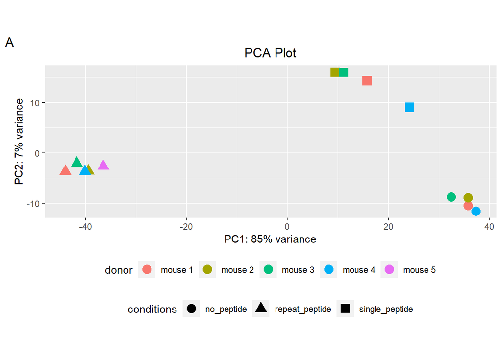

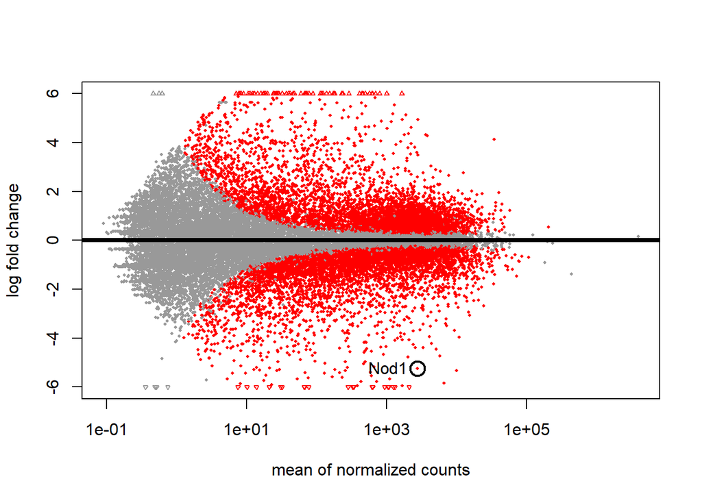

```r
library(DESeq2)

library(SummarizedExperiment)
library(Rgraphviz)
library(GenomeInfoDb)

chooseCRANmirror(graphics=FALSE, ind=1)
knitr::opts_chunk$set(echo = TRUE)

countdata<-read.csv("~/rna_seq/week1/GSE150120_str-ReadCount.tab", header=TRUE, sep = "", row.names=NULL)

countdata<-as.data.frame(countdata)
names<-countdata$row.names
countdata<-countdata[,-1]
countdata<-as.matrix(countdata)
rownames(countdata)<-names
countdata<-abs(countdata)
#Summarized Experiment
Se<-SummarizedExperiment(assays = list(counts=countdata))

conditions<- c("repeat_peptide","no_peptide","single_peptide")

x<-paste("mouse",1:4)
y<-rep(x,3)
y<-sort(y, na.last = TRUE ,decreasing = FALSE)
donor<-c(y,"mouse 5")


coldata<-as.data.frame(cbind(colnames(countdata), donor, conditions))

#DESEQ2
dds<-DESeqDataSetFromMatrix(countData = countdata,
                       colData = coldata,
                       design = ~conditions+donor)
dds<-DESeq(dds)

#Pre-filtering Dataset

dds <- dds[rowSums(counts(dds))>1]


#variance stabilizing transformation for stabilizing the count data variance across mean
vsd<-vst(dds, blind = FALSE)

library(ggplot2)
library(dplyr)


pcaData<-plotPCA(vsd, intgroup=c("conditions","donor"), returnData=TRUE)

#Finding the PCA percentage
percentVar <- round(100 * attr(pcaData, "percentVar"))


#results table, (padj=q-value)

res<-results(dds, alpha = 0.1, contrast =
              c("conditions","repeat_peptide","single_peptide"))

topGene <- rownames(res)[which.min(res$padj)]


ggplot(pcaData, aes(x = PC1, y = PC2, color = donor, shape = conditions)) +
  geom_point(size =4) +
  xlab(paste0("PC1: ", percentVar[1], "% variance")) +
  ylab(paste0("PC2: ", percentVar[2], "% variance")) +
  coord_fixed() + labs(tag="A")+
  ggtitle("PCA Plot")+theme(plot.title = element_text(hjust = 0.5), legend.box = "vertical", legend.position = "bottom")
plotMA(res,alpha=0.1, colSig="red",colLine="black", ylim = c(-6,6))+
with(res[topGene, ], {
  points(baseMean, log2FoldChange, col="black", cex=2, lwd=2)
  text(baseMean, log2FoldChange, topGene, pos=2, col="black")
})
```

**Figure 1.RNA-Seq analysis** A.Dimension reduction plot of RNA-Seq result which shows that the cells from same cultures cluster together while different cultures cluster away from each other. There is no outliers considering the plot. B.MA plot showing the mean variance and the lowest adjusted p-value is labeled on the plot as Nod1 gene. Each gene is plotted as a dot. Genes having an adjusted p-value below a threshold of 0.1 is depicted as red. Black line indicates the difference between upregulated and down regulated genes.

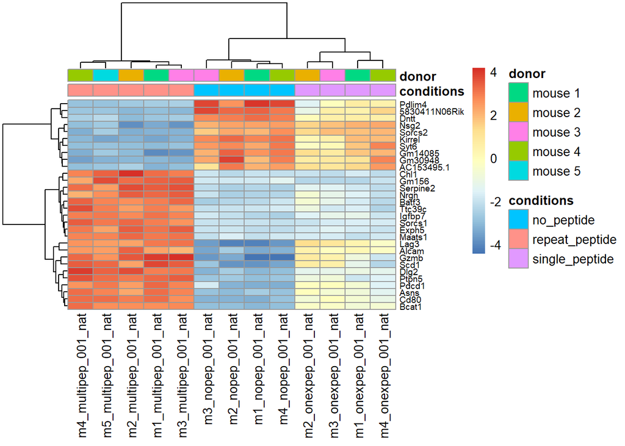

```r
library("genefilter")
topVarGenes <- head(order(rowVars(assay(vsd)), decreasing = TRUE), 30)
mat  <- assay(vsd)[ topVarGenes, ]
mat  <- mat - rowMeans(mat)
anno_mat <- as.data.frame(colData(vsd)[, c("conditions","donor")])
pheatmap::pheatmap(mat, annotation_col = anno_mat, angle_col = c("90"),fontsize_row = 7)
```

**Figure 2.Heatmap of relative variance stabilizating-transformed values across samples** Heatmap shows the clustering of genes in each sample.30 most variable genes are selected and mapped across all samples.It shows how much of each gene deviates in a specific sample from the gene’s average across samples. A set of genes are found to be increased in exhausted cells separating the effector and naive cell genes.

## Gene Ontology Enrichment Analysis

```r
overallBaseMean <- as.matrix(res[, "baseMean", drop = F])
sigGenes <- rownames(subset(res, padj < 0.1))
match_genes<-match(sigGenes, rownames(overallBaseMean))
library(genefilter)
backG <- c()
for(i in match_genes){

    ind <-  genefinder(overallBaseMean, i, 10, method = "manhattan")[[1]]$indices

    backG <- c(backG, ind)

    }

backG <- unique(backG)
backG <- rownames(overallBaseMean)[backG]
backG <- setdiff(backG, sigGenes)


library("org.Mm.eg.db")
anno <- AnnotationDbi::select(org.Mm.eg.db,
              keys=rownames(res),
              columns=c("ENSEMBL","SYMBOL", "GENENAME"),
              keytype ="SYMBOL")

anSig <- as.data.frame(subset(anno, SYMBOL %in% sigGenes))

onts = c( "MF", "BP", "CC" )

geneIDs = rownames(overallBaseMean)
inUniverse = geneIDs %in% c(anSig$SYMBOL,  backG)
inSelection =  geneIDs %in% anSig$SYMBOL
alg <- factor( as.integer( inSelection[inUniverse] ) )
names(alg) <- geneIDs[inUniverse]

library("topGO")
tab = as.list(onts)
names(tab) = onts
  for(i in 1:3){

  ## prepare data
  GOdata <- new("topGOdata", ontology=onts[i], allGenes = alg, nodeSize=5,
                 annot=annFUN.org, mapping="org.Mm.eg.db", ID = "symbol" )

  ## run tests
    resultTopGO.elim <- runTest(GOdata, algorithm = "elim", statistic = "Fisher" )
    resultTopGO.classic <- runTest(GOdata, algorithm = "classic", statistic = "Fisher" )

  ## look at results
    tab[[i]] <- GenTable(GOdata, Fisher.elim = resultTopGO.elim,
        Fisher.classic = resultTopGO.classic,
        orderBy = "Fisher.classic" , topNodes = 200)
  }

par(mfrow=c(1,2))
go_table<-tab$BP[order(tab$BP$Fisher.classic, decreasing = FALSE),][1:10,]
go_table<-go_table[,-6]
knitr::kable(go_table, align = "ccccccc", label = "A")
```

|  | GO.ID | Term | Annotated | Significant | Expected | Fisher.elim | Fisher.classic |
| --- | --- | --- | --- | --- | --- | --- | --- |
| 83 | GO:0008213 | protein alkylation | 156 | 116 | 93.49 | 1.00000 | 0.00010 |
| 84 | GO:0006479 | protein methylation | 156 | 116 | 93.49 | 0.00694 | 0.00010 |
| 85 | GO:0032944 | regulation of mononuclear cell prolifera… | 186 | 136 | 111.47 | 0.35883 | 0.00011 |
| 86 | GO:0050727 | regulation of inflammatory response | 262 | 186 | 157.01 | 0.00891 | 0.00011 |
| 87 | GO:0005975 | carbohydrate metabolic process | 420 | 288 | 251.70 | 0.00366 | 0.00012 |
| 88 | GO:0031326 | regulation of cellular biosynthetic proc… | 2931 | 1843 | 1756.53 | 0.18980 | 0.00013 |
| 89 | GO:0045582 | positive regulation of T cell differenti… | 86 | 68 | 51.54 | 0.00386 | 0.00013 |
| 90 | GO:0045621 | positive regulation of lymphocyte differ… | 99 | 77 | 59.33 | 0.34771 | 0.00013 |
| 91 | GO:0042098 | T cell proliferation | 176 | 129 | 105.48 | 0.07089 | 0.00013 |
| 92 | GO:0050794 | regulation of cellular process | 7607 | 4663 | 4558.81 | 0.31725 | 0.00015 |

```r
go_table<-tab$BP[order(tab$BP$Fisher.elim, decreasing = FALSE),][1:10,]
go_table<-go_table[,-7]
knitr::kable(go_table, align = "ccccccc",label = "B")
```

|  | GO.ID | Term | Annotated | Significant | Expected | Rank in Fisher.classic | Fisher.classic |
| --- | --- | --- | --- | --- | --- | --- | --- |
| 102 | GO:0046640 | regulation of alpha-beta T cell prolifer… | 31 | 28 | 18.58 | 102 | 0.00020 |
| 42 | GO:0006974 | cellular response to DNA damage stimulus | 669 | 456 | 400.93 | 42 | 3.9e-06 |
| 65 | GO:1903047 | mitotic cell cycle process | 605 | 409 | 362.57 | 65 | 4.1e-05 |
| 126 | GO:0071346 | cellular response to interferon-gamma | 85 | 66 | 50.94 | 126 | 0.00041 |
| 147 | GO:2000772 | regulation of cellular senescence | 36 | 31 | 21.57 | 147 | 0.00063 |
| 160 | GO:0009154 | purine ribonucleotide catabolic process | 19 | 18 | 11.39 | 160 | 0.00081 |
| 175 | GO:0097549 | chromatin organization involved in negat… | 72 | 56 | 43.15 | 175 | 0.00104 |
| 189 | GO:0045190 | isotype switching | 45 | 37 | 26.97 | 189 | 0.00119 |
| 191 | GO:1905048 | regulation of metallopeptidase activity | 13 | 13 | 7.79 | 191 | 0.00128 |
| 192 | GO:0043248 | proteasome assembly | 13 | 13 | 7.79 | 192 | 0.00128 |

**Table 1.Gene ontology enrichment results of the biological processes** First 10 term from biological process of GO data are ordered from the lowest Fisher value using classic algorithm showing the corresponding terms in the right table. First 10 term from biological process of GO data are ordered from the lowest Fisher value using elim algorithm showing the corresponding terms in the left table.

After comparing the 10 most significant GO terms and checking whether the terms are relevant to the experiment, an acyclic graph is formed from the terms involved in biological processes. The acyclic graph in Figure 3. displays that metabolic process, immune system process, response to stress, and cellular process are the significant GO terms taking place in the biological processes of the exhausted CD8+ T cells. The immune process in the graph includes regulation of T cell activation, while the more significant terms metabolic process includes cellular macromolecule biosynthetic process and cellular process includes positive regulation of cell-cell adhesion.

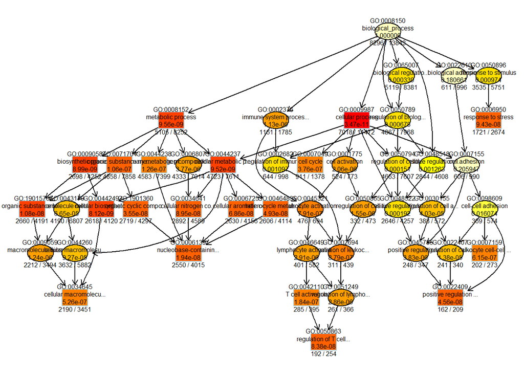

```
## $dag
## A graphNEL graph with directed edges
## Number of Nodes = 45
## Number of Edges = 75
##
## $complete.dag
## [1] "A graph with 45 nodes."
```

```r
onts2<-c("BP")
GOdata_BP <- new("topGOdata", ontology=onts2, allGenes = alg, nodeSize=5,
                 annot=annFUN.org, mapping="org.Mm.eg.db", ID = "symbol" )
resultTopGO.classic_BP <- runTest(GOdata_BP, algorithm = "classic", statistic = "Fisher" )
par(cex=0.3)
showSigOfNodes(GOdata_BP, termsP.value =score(resultTopGO.classic_BP), firstSigNodes = 20, useFullNames = TRUE, useInfo = "all")
```

**Figure 3.Acyclic graph of gene ontology enrichment results** Subgraph induced by the top 20 significant GO terms are identified by the classic algorithm for scoring GO terms for enrichment. Rectangles indicate the 20 most significant terms. Rectangle color represents the relative significance, ranging from dark red (most significant) to bright yellow (least significant).

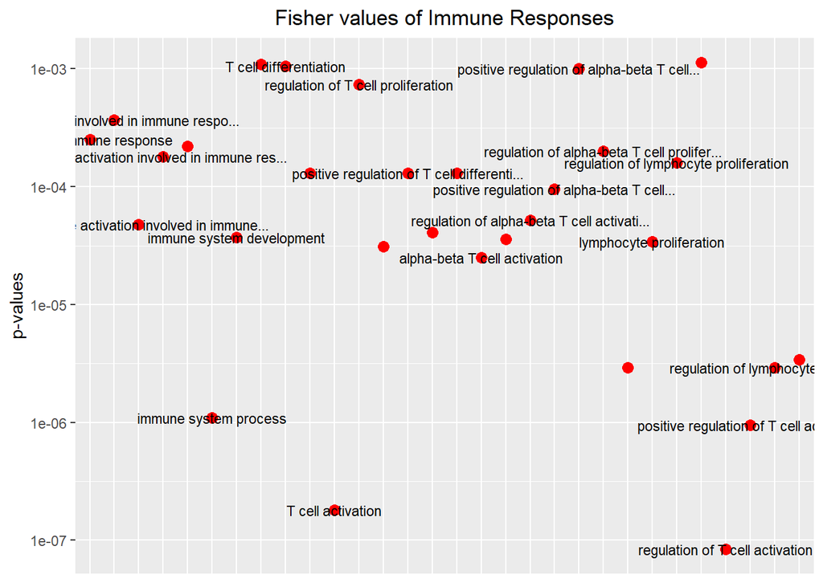

```r
library(stringr)
library(dplyr)


immune_GOdata<-tab$BP[str_detect(tab$BP$Term, "(T cell)|(lymphocyte)|(immune)"),]

immune_GOdata$Fisher.classic<-as.numeric(immune_GOdata$Fisher.classic)
library(ggplot2)


ggplot(immune_GOdata, aes(x=immune_GOdata$GO.ID, y=(immune_GOdata$Fisher.classic)), label_value(immune_GOdata$Term))+geom_point(size=3, col="red")+ geom_text(label=immune_GOdata$Term,position = "identity", size=3, check_overlap = TRUE)+theme(axis.text.x = element_blank(), axis.ticks.x = element_blank(), axis.title.x = element_blank(),plot.title = element_text(hjust = 0.5))+scale_y_log10()+ylab("p-values")+labs(title = "Fisher values of Immune Responses")
```

**Figure 4.Immunological terms are graphed according to their Fisher values** GO data containing the biological processes are filtered the GO.IDs containing a function related to T cells. y-axis shows the p-values corresponding to each term.

## Correlation Results

Differential gene expression analysis and gene ontology enrichment analysis give us an idea of how the exhaustion state differs from the functional effector state. However, there is still a need to check the results and genes by comparing other datasets so that more relevant and consistent results could be obtained. Moreover, the biases would be minimized with the larger dataset. So, there are three more datasets that also investigate the exhausted T cells transcriptome with bulk RNA-seq. The first of the dataset could be accessed from GEO with GSE132984. The experiment uses the Tox transcription factor which is an important exhaustion regulator in CD8+ T cells when its expression is increased. TOX is known to play a main role in the exhaustion induction in the CD8+T cells, therefore in this study the transcriptional profile of wildtype P14 T cells are compared with the TOX-/- mutant P14 T cells which are produced by transduction of TOX-encoding retrovirus following 8 days of Cl-13 infection. Due to the TOX gene’s fundamental role in leading to the exhaustion state, two CD8+ T cell populations are created with wildtype and mutant in which wildtype forms an exhausted CD8+ T cell population while the mutant forms a non-exhausted CD8+ T cell population. RNA-Seq data is used to compare the transcriptional features of the exhausted CD8+ T cells and to find the differentially expressed genes in this dataset. Later, log fold change and stat values for the first highest 100 genes are selected from the results of this experiment and the previous experiment, and a correlation analysis is performed to measure the linear correlation between them via Pearson’s correlation.

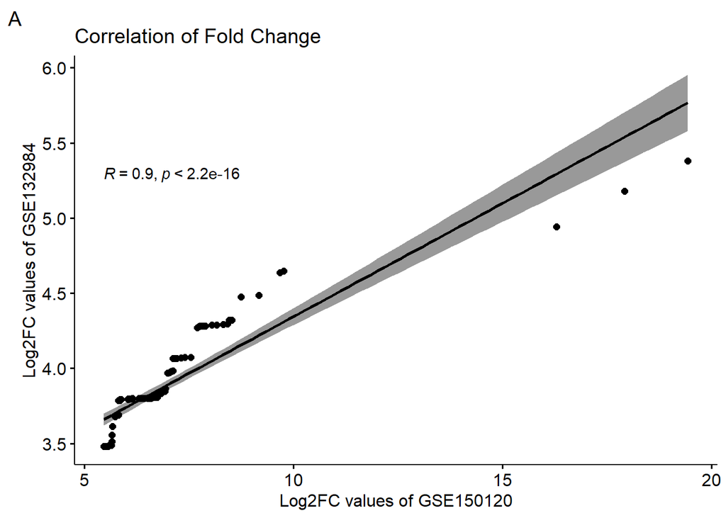

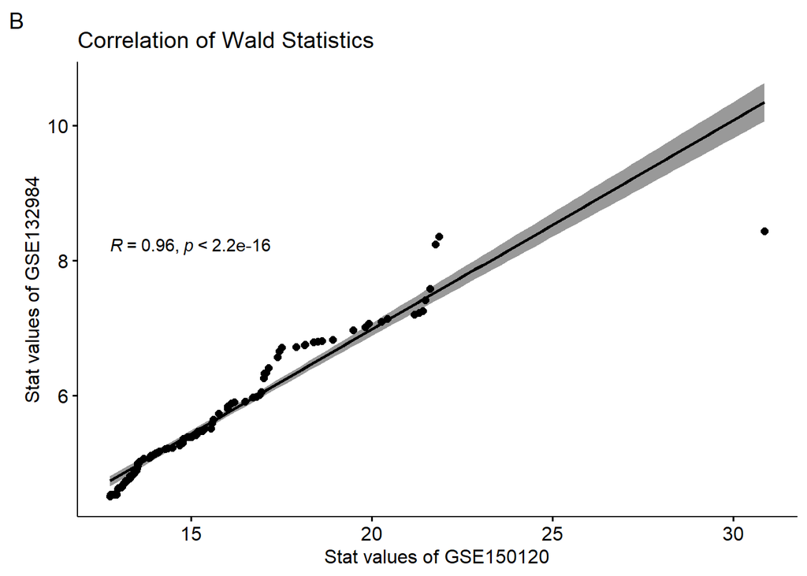

```r
tox_data_control1<-read.table("~/rna_seq/tox_data/GSM3897726_R_OK_S108_RNA_counts.txt.gz",sep ="" , row.names = NULL, as.is=TRUE)
colnames(tox_data_control1)<-c("Genes","Control1")
tox_data_control2<-read.table("~/rna_seq/tox_data/GSM3897727_R_OK_S109_RNA_counts.txt.gz",sep ="" , row.names = NULL, as.is=TRUE)
colnames(tox_data_control2)<-c("Genes","Control2")
tox_data_rep1<-read.table("~/rna_seq/tox_data/GSM3897728_R_OK_S110_RNA_counts.txt.gz",sep ="" , row.names = NULL, as.is=TRUE)
colnames(tox_data_rep1)<-c("Genes","Tox-/- rep1")
tox_data_rep2<-read.table("~/rna_seq/tox_data/GSM3897729_R_OK_S111_RNA_counts.txt.gz",sep ="" ,  row.names = NULL, as.is=TRUE)
colnames(tox_data_rep2)<-c("Genes","Tox-/- rep2")
tox_data_rep3<-read.table("~/rna_seq/tox_data/GSM3897730_R_OK_S112_RNA_counts.txt.gz",sep ="" , row.names = NULL, as.is=TRUE)
colnames(tox_data_rep3)<-c("Genes","Tox-/- rep3")

all_data<-cbind(tox_data_control1, tox_data_control2, tox_data_rep1, tox_data_rep2, tox_data_rep3)
all_data<-all_data[,-c(3,5,7,9)]
all_names<-all_data$Genes
all_data<-all_data[,-1]
all_data<-as.matrix(all_data)
rownames(all_data)<-all_names
all_data<-abs(all_data)
all_data<-as.data.frame(all_data)

tox_Se<-SummarizedExperiment(assays = list(counts=all_data))
tox_sample<-c("WT","WT","TOX-/-","TOX-/-","TOX-/-")
tox_cells<-rep("P14",5)
tox_coldata<-as.data.frame(cbind(colnames(all_data), tox_sample, tox_cells))



tox_dds<-DESeqDataSetFromMatrix(countData = all_data,
                                colData = tox_coldata,
                                design=~tox_sample)
tox_dds<-DESeq(tox_dds)
tox_dds<-tox_dds[rowSums(counts(tox_dds))>1]
tox_result<-results(tox_dds,alpha = 0.1, contrast = c("tox_sample","WT","TOX-/-"))



res_sig<-res[order(res$log2FoldChange, decreasing = TRUE),][1:100,]
tox_sig<-tox_result[order(tox_result$log2FoldChange, decreasing = TRUE),][1:100,]
res_stat<-res[order(res$stat, decreasing = TRUE),][1:100,]
tox_stat<-tox_result[order(tox_result$stat, decreasing = TRUE),][1:100,]
par(mfrow=c(1,2))
ggpubr::ggscatter(as.data.frame(cbind(res_sig$log2FoldChange,tox_sig$log2FoldChange)),x="V1", y="V2", add = "reg.line", conf.int = TRUE,
          cor.coef = TRUE, cor.method = "pearson", xlab = "Log2FC values of GSE150120",ylab = "Log2FC values of GSE132984", title = "Correlation of Fold Change")+labs(tag = "A")
ggpubr::ggscatter(as.data.frame(cbind(res_stat$stat, tox_stat$stat)),x="V1", y="V2", add = "reg.line", conf.int = TRUE,
          cor.coef = TRUE, cor.method = "pearson", xlab = "Stat values of GSE150120",ylab = "Stat values of GSE132984",title="Correlation of Wald Statistics")+labs(tag = "B")
```

**Figure 5. Correlation plot of GSE132984 and GSE150120 are shown.** A. Log2 fold change is compared between these datasets with the Pearson’s correlation method. The fisrt 100 genes with the highest log2 fold change are chosen for both of the dataset. B. Stat values are compared between these dataset with the Pearson’s correlation method. The fisrt 100 genes with the highest stat values are chosen for both of the dataset.(p<2e-16)

After the correlation analysis, another data again studying the transcriptome of exhaustion in CD8+ T cell is added. This third data included in the report has an access number of GSE93006. In this set of experiments, C57BL/6 mice are injected with B16-OVA, a melanoma cell line to produce exhausted cytotoxic T lymphocytes (CTLs). Furthermore, a low number of OT-I tumor-specific CD8+ T cells are injected into the tumor-bearing mice together with P-14 CD8+ T cells which, on the contrary to OT-I cells, are tumor-ignorant. Therefore, the melanoma tumor in the mice causes OT-I tumor-infiltrating lymphocytes (TILs) to become exhausted after 8 days whereas the tumor-ignorant P-14 TILs don’t interact with the tumor cells and maintain the effector T cell features. The results from the differential gene expression are again plotted against our main data (GSE150120) to check for correlation.

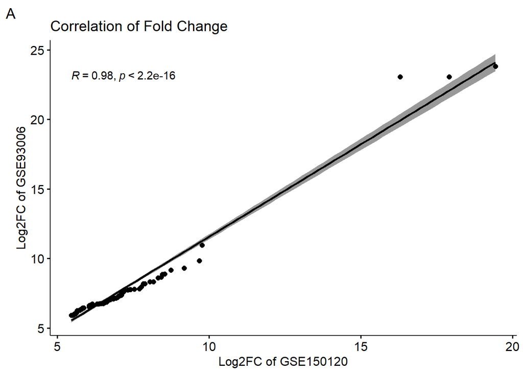

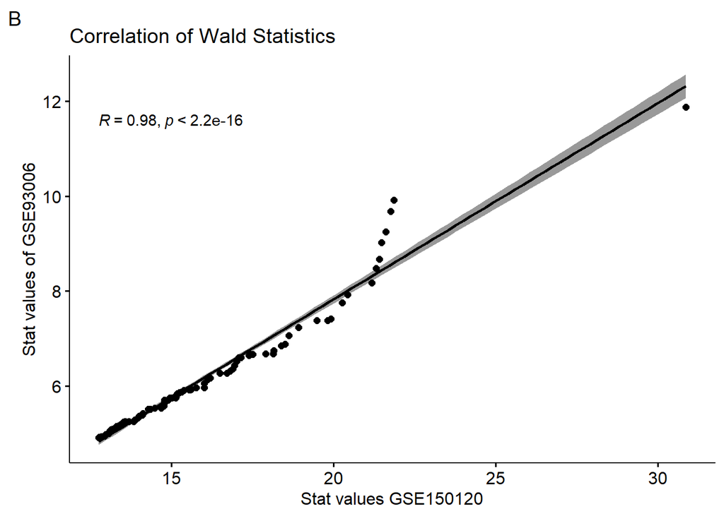

```r
comparison_data<-read.table("~/rna_seq/GSE93006_counts.txt.gz",sep ="" , header =TRUE, row.names = NULL, as.is=TRUE)

comparison_data<-comparison_data[,c(1,7:14)]
comparison_data<-as.data.frame(comparison_data)
library(stringr)
comparison_data$Geneid<-word(comparison_data$Geneid,1,sep = "\\.")
names(comparison_data)[1]<-"ENSEMBL"
rownames(comparison_data)<-comparison_data$ENSEMBL



anno_comparison <- AnnotationDbi::select(org.Mm.eg.db,
              keys=rownames(comparison_data),
              columns=c("ENSEMBL","SYMBOL"),
              keytype ="ENSEMBL")
library(dplyr)
comparison_data<-inner_join(anno_comparison, comparison_data, by="ENSEMBL")
name2<-comparison_data$SYMBOL
comparison_data<-comparison_data[,-c(1,2)]
comparison_data<-as.matrix(comparison_data)
rownames(comparison_data)<-name2
comparison_data<-as.data.frame(comparison_data)
comparison_data<-abs(comparison_data)


comparison_Se<-SummarizedExperiment(assays = list(counts=comparison_data))
comparison_sample<-c("OTI_1","OTI_2","OTI_3","P14_1","P14_2","P14_3","P14_4","P14_5")
cells<-c("OTI","OTI","OTI","P14","P14","P14","P14","P14")

comparison_coldata<-as.data.frame(cbind(colnames(comparison_data), comparison_sample, cells))


comparison_Dds<-DESeqDataSetFromMatrix(countData = comparison_data,
                                       colData = comparison_coldata,
                                       design = ~cells)

comparison_Dds<-DESeq(comparison_Dds)
comparison_Dds<-comparison_Dds[rowSums(counts(comparison_Dds))>1]
comparison_result<-results(comparison_Dds,alpha = 0.1, contrast = c("cells","OTI","P14"))

comp_sig<-comparison_result[order(comparison_result$log2FoldChange, decreasing = TRUE),][1:100,]
comp_stat<-comparison_result[order(comparison_result$stat, decreasing = TRUE),][1:100,]

par(mfrow=c(1,2))
R<-cbind(res_sig$log2FoldChange, comp_sig$log2FoldChange)
R<-as.data.frame(R)
ggpubr::ggscatter(R,x="V1", y="V2", add = "reg.line", conf.int = TRUE,
          cor.coef = TRUE, cor.method = "pearson", xlab = "Log2FC of GSE150120",ylab = "Log2FC of GSE93006", title = "Correlation of Fold Change")+labs(tag = "A")

ggpubr::ggscatter(as.data.frame(cbind(res_stat$stat, comp_stat$stat)),x="V1", y="V2", add = "reg.line", conf.int = TRUE,
          cor.coef = TRUE, cor.method = "pearson", xlab = "Stat values GSE150120",ylab = "Stat values of GSE93006",title="Correlation of Wald Statistics")+labs(tag = "B")
```

**Figure 6. Correlation plot of GSE93006 and GSE150120** A. This correlation plot is done with the initial data(GSE150120) and the third data(GSE93006) to compare log2 fold change. The 100 genes having the greatest log2 fold change are selected from both datasets. Correlation coefficient is almost 1 and the variables are positively correlated. B. The 100 greatest stat values selected from both of the data are compared and they are positively correlated and the correlation is highly significant.(p<2e-16)

Considering the plots in Figure 6., the log fold change values are similar between the two datasets however, the stat values in GSE93006 are almost half of the GSE150120. Nevertheless, both of the correlation plots in the figure represent a positive correlation in the fold changes and the stat values.

The last and the fourth data used in this report has an accession number of GSE88987. In this experiment, CD8+T cells are collected after the LCMV infection on day 8, day 20, and day 35 to be sorted in FACS according to their effector, memory, or exhaustion markers. The 8 days of virally infected mice are used to collect the effector T cells, the 20 days, infected mice are used to collect the exhausted T cells and the 35 days-infected T cells are used to obtain memory T cells. The cells without any treatment, naive T cells, are also used in the RNA-seq analysis, and bulk RNA-Seq analysis is performed on all subtypes of CD8+T cells. Again a correlation analysis is done between the results of this experiment and the first data, GSE150120.

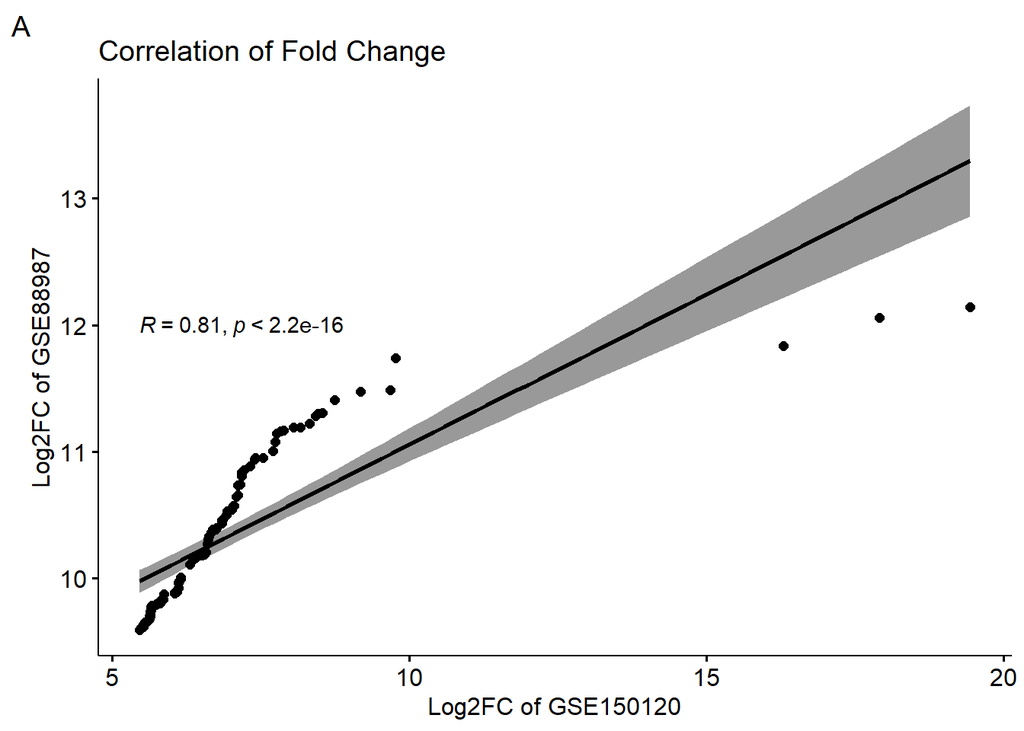

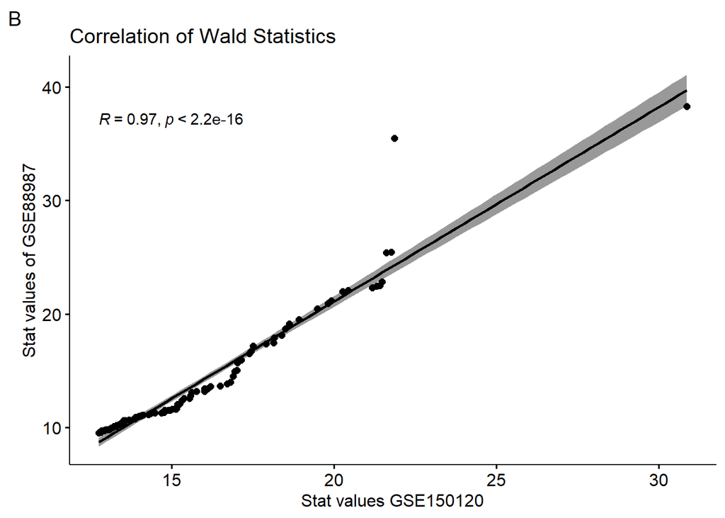

```r
naive_rep1<-read.table("~/rna_seq/data_5/GSM2356816.ReadsPerGene.out.tab",sep ="" , header =TRUE, row.names = NULL, as.is=TRUE)
naive_names<-naive_rep1$N_unmapped
rownames(naive_rep1)<-naive_names
naive_rep1<-naive_rep1[-c(1:3),-1]
naive_rep1<-cbind(naive_rep1, rowMeans(naive_rep1))

naive_rep2<-read.table("~/rna_seq/data_5/GSM2356817.ReadsPerGene.out.tab",sep ="" , header =TRUE, row.names = NULL, as.is=TRUE)
rownames(naive_rep2)<-naive_rep2$N_unmapped
naive_rep2<-naive_rep2[-c(1:3),-1]
naive_rep2<-cbind(naive_rep2, rowMeans(naive_rep2))

effector_rep1<-read.table("~/rna_seq/data_5/GSM2356818.ReadsPerGene.out.tab",sep ="" , header =TRUE, row.names = NULL, as.is=TRUE)
rownames(effector_rep1)<-effector_rep1$N_unmapped
effector_rep1<-effector_rep1[-c(1:3),-1]
effector_rep1<-cbind(effector_rep1, rowMeans(effector_rep1))

effector_rep2<-read.table("~/rna_seq/data_5/GSM2356819.ReadsPerGene.out.tab",sep ="" , header =TRUE, row.names = NULL, as.is=TRUE)
rownames(effector_rep2)<-effector_rep2$N_unmapped
effector_rep2<-effector_rep2[-c(1:3),-1]
effector_rep2<-cbind(effector_rep2, rowMeans(effector_rep2))

memory_rep1<-read.table("~/rna_seq/data_5/GSM2356820.ReadsPerGene.out.tab",sep ="" , header =TRUE, row.names = NULL, as.is=TRUE)
rownames(memory_rep1)<-memory_rep1$N_unmapped
memory_rep1<-memory_rep1[-c(1:3),-1]
memory_rep1<-cbind(memory_rep1, rowMeans(memory_rep1))

memory_rep2<-read.table("~/rna_seq/data_5/GSM2356821.ReadsPerGene.out.tab",sep ="" , header =TRUE, row.names = NULL, as.is=TRUE)
rownames(memory_rep2)<-memory_rep2$N_unmapped
memory_rep2<-memory_rep2[-c(1:3),-1]
memory_rep2<-cbind(memory_rep2, rowMeans(memory_rep2))

exhaustion_rep1<-read.table("~/rna_seq/data_5/GSM2356822.ReadsPerGene.out.tab",sep ="" , header =TRUE, row.names = NULL, as.is=TRUE)
rownames(exhaustion_rep1)<-exhaustion_rep1$N_unmapped
exhaustion_rep1<-exhaustion_rep1[-c(1:3),-1]
exhaustion_rep1<-cbind(exhaustion_rep1, rowMeans(exhaustion_rep1))

exhaustion_rep2<-read.table("~/rna_seq/data_5/GSM2356823.ReadsPerGene.out.tab",sep ="" , header =TRUE, row.names = NULL, as.is=TRUE)
rownames(exhaustion_rep2)<-exhaustion_rep2$N_unmapped
exhaustion_rep2<-exhaustion_rep2[-c(1:3),-1]
exhaustion_rep2<-cbind(exhaustion_rep2, rowMeans(exhaustion_rep2))

data_all<-cbind(naive_rep1,naive_rep2,effector_rep1,effector_rep2,memory_rep1,memory_rep2, exhaustion_rep1,exhaustion_rep2)
data_all<-abs(data_all)
data_all<-data_all[,c(4,8,12,16,20,24,28,32)]


library("org.Mm.eg.db")
anno_Data<-AnnotationDbi::select(org.Mm.eg.db,
                                 keys=rownames(data_all),
                                 columns=c("SYMBOL"),
                                 keytype ="ENSEMBL")

data_all$ENSEMBL<-rownames(data_all)
data_all<-left_join(data_all,anno_Data, by="ENSEMBL")
data_names<-data_all$SYMBOL
data_all<-as.matrix(data_all)
rownames(data_all)<-data_names

data_all<-as.data.frame(data_all)
data_all<-data_all[,-c(9,10)]
data_all<-na.omit(data_all)

library(DESeq2)
data_Se<-SummarizedExperiment(assays = list(counts=data_all))
data_sample<-c("naive","naive","effector","effector","memory","memory","exhaustion","exhaustion")
data_cells<-rep("CD8",8)
data_coldata<-as.data.frame(cbind(colnames(data_all), data_sample, data_cells))


cols_to_num = c(1:8)
for(i in cols_to_num){
   class(data_all[, i]) = "numeric"
}

cols_to_int = c(1:8)
for(i in cols_to_int){
   class(data_all[, i]) = "integer"
}
data_dds<-DESeqDataSetFromMatrix(countData =(data_all),
                                colData = data_coldata,
                                design= ~data_sample)


data_dds<-DESeq(data_dds)
data_dds<-data_dds[rowSums(counts(data_dds))>1]


data_result<-results(data_dds, alpha = 0.1,contrast = c("data_sample","effector","exhaustion"))


data_sig<-data_result[order(data_result$log2FoldChange, decreasing = TRUE),][1:100,]
data_stat<-data_result[order(data_result$stat, decreasing = TRUE),][1:100,]


par(mfrow=c(1,2))
ggpubr::ggscatter(as.data.frame(cbind(res_sig$log2FoldChange, data_sig$log2FoldChange)),x="V1", y="V2", add = "reg.line", conf.int = TRUE,
          cor.coef = TRUE, cor.method = "pearson", xlab = "Log2FC of GSE150120",ylab = "Log2FC of GSE88987",title = "Correlation of Fold Change")+labs(tag = "A")
ggpubr::ggscatter(as.data.frame(cbind(res_stat$stat, data_stat$stat)),x="V1", y="V2", add = "reg.line", conf.int = TRUE,
          cor.coef = TRUE, cor.method = "pearson", xlab = "Stat values GSE150120",ylab = "Stat values of GSE88987",title="Correlation of Wald Statistics")+labs(tag = "B")
```

There is a positive, linear, and significant correlation between the log fold changes and the stat values when the two datasets are compared according to the plots in Figure 7 as in the previous correlation plots. But this time both the log fold changes and the stat values are relatively similar to the main data(GSE150120).

## Meta-Analysis

In fundamental part of the analysis is to combine all the datasets examined previously to perform a meta-analysis. With the meta-analysis, the more precise and accurate genes that are relevant to exhausted CD8+ T cells transcriptome could be determined. Meta-analysis results in two tests called Fisher’s and Stouffer’s which are required to combine p-values with different statistical properties.[6] It has been proven that combining p-values from independent studies for multiple hypothesis testing lowers the Type I error and there is no consistently most powerful test. Therefore, combining the p-values and comparing different tests would be helpful. For example, Fisher’s test is more robust than the z-test, however, having the same effect sizes makes the z-test more powerful than Fisher’s test.[7] Considering these reasons, both Fisher’s and Stouffer’s tests are used in this meta-analysis.

Meta-analysis of all four RNA-Seq data displays 3937 and 3679 upregulated genes in Fisher’s and Stouffer’s tests, respectively. However, it has been found that only 56 and 146 genes are downregulated significantly according to these tests. The heatmaps in Figure 8. show 30 genes with the lowest p-values in both of the tests so that the differences between the tests could be observed as well as the gene varieties.

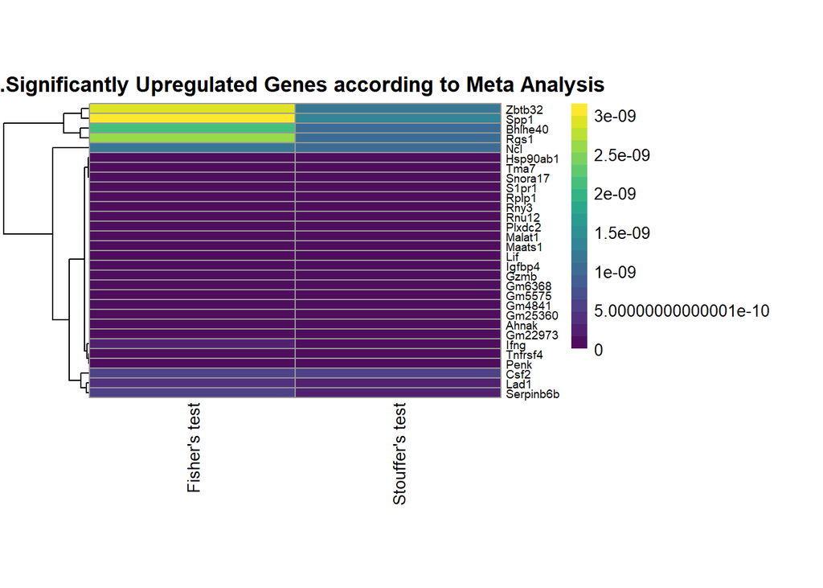

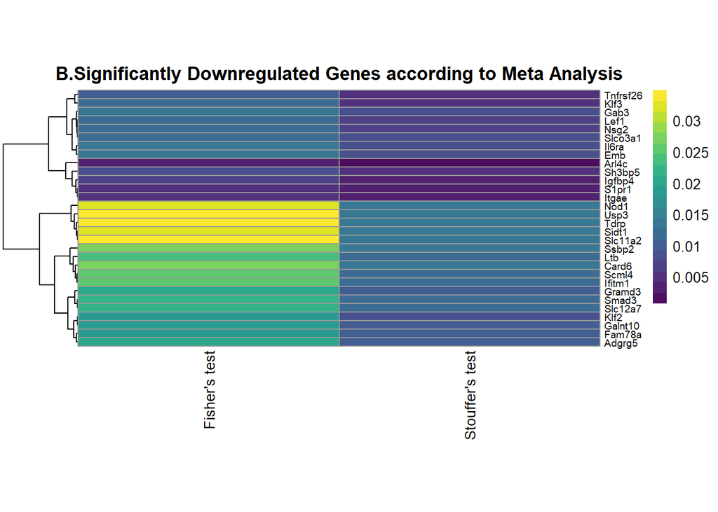

```r
StudyA<-read.table("~/rna_seq/week1/GSE150120_str-ReadCount.tab", sep ="" , header =TRUE, as.is=TRUE, row.names = NULL)
names<-StudyA$row.names
StudyA<-StudyA[,-1]
StudyA<-as.matrix(StudyA)
rownames(StudyA)<-names
StudyA<-as.data.frame(StudyA)
StudyA<-abs(StudyA)
StudyA<-cbind(StudyA, names)


colnames(StudyA)<-c("A_1","A_2","A_3","A_4","A_5","A_6","A_7","A_8","A_9","A_10","A_11","A_12","A_13","names")

row.names(StudyA)<-StudyA$row.names

StudyB<-read.table("~/rna_seq/GSE93006_counts.txt.gz",sep ="" , header =TRUE, row.names = NULL, as.is=TRUE)
library(stringr)
library(dplyr)
StudyB$Geneid<-word(StudyB$Geneid,1,sep = "\\.")
names(StudyB)[1]<-"ENSEMBL"
StudyB<-StudyB[,c(1,7:14)]
names_b<-StudyB$ENSEMBL
StudyB<-as.matrix(StudyB)
rownames(StudyB)<-names_b
StudyB<-as.data.frame(StudyB)
library("org.Mm.eg.db")
anno_comparison<-AnnotationDbi::select(org.Mm.eg.db,
                                         keys=rownames(StudyB),
                                         columns=c("ENSEMBL","SYMBOL"),
                                         keytype ="ENSEMBL")


StudyB<-inner_join(anno_comparison, StudyB, by="ENSEMBL")
name2<-StudyB$SYMBOL
StudyB<-StudyB[,-c(1,2)]
StudyB<-as.matrix(StudyB)
rownames(StudyB)<-name2
StudyB<-as.data.frame(StudyB)
StudyB$names<-rownames(StudyB)
colnames(StudyB)<-c("B_1","B_2","B_3","B_4","B_5","B_6","B_7","B_8","names")

#Merging countdata and comparison_data

x_in<-inner_join(StudyA, StudyB, by="names")


tox_data_control1<-read.table("~/rna_seq/tox_data/GSM3897726_R_OK_S108_RNA_counts.txt.gz",sep ="" , row.names = NULL, as.is=TRUE)
colnames(tox_data_control1)<-c("Genes","Control1")
tox_data_control2<-read.table("~/rna_seq/tox_data/GSM3897727_R_OK_S109_RNA_counts.txt.gz",sep ="" , row.names = NULL, as.is=TRUE)
colnames(tox_data_control2)<-c("Genes","Control2")
tox_data_rep1<-read.table("~/rna_seq/tox_data/GSM3897728_R_OK_S110_RNA_counts.txt.gz",sep ="" , row.names = NULL, as.is=TRUE)
colnames(tox_data_rep1)<-c("Genes","Tox-/- rep1")
tox_data_rep2<-read.table("~/rna_seq/tox_data/GSM3897729_R_OK_S111_RNA_counts.txt.gz",sep ="" ,  row.names = NULL, as.is=TRUE)
colnames(tox_data_rep2)<-c("Genes","Tox-/- rep2")
tox_data_rep3<-read.table("~/rna_seq/tox_data/GSM3897730_R_OK_S112_RNA_counts.txt.gz",sep ="" , row.names = NULL, as.is=TRUE)
colnames(tox_data_rep3)<-c("Genes","Tox-/- rep3")

StudyC<-cbind(tox_data_control1, tox_data_control2, tox_data_rep1, tox_data_rep2, tox_data_rep3)
StudyC<-StudyC[,-c(3,5,7,9)]
colnames(StudyC)<-c("names","C_1","C_2","C_3","C_4","C_5")


z<-inner_join(x_in, StudyC, by="names")



naive_rep1<-read.table("~/rna_seq/data_5/GSM2356816.ReadsPerGene.out.tab",sep ="" , header =TRUE, row.names = NULL, as.is=TRUE)
naive_names<-naive_rep1$N_unmapped
rownames(naive_rep1)<-naive_names
naive_rep1<-naive_rep1[-c(1:3),-1]
naive_rep1<-cbind(naive_rep1, rowMeans(naive_rep1))

naive_rep2<-read.table("~/rna_seq/data_5/GSM2356817.ReadsPerGene.out.tab",sep ="" , header =TRUE, row.names = NULL, as.is=TRUE)
rownames(naive_rep2)<-naive_rep2$N_unmapped
naive_rep2<-naive_rep2[-c(1:3),-1]
naive_rep2<-cbind(naive_rep2, rowMeans(naive_rep2))

effector_rep1<-read.table("~/rna_seq/data_5/GSM2356818.ReadsPerGene.out.tab",sep ="" , header =TRUE, row.names = NULL, as.is=TRUE)
rownames(effector_rep1)<-effector_rep1$N_unmapped
effector_rep1<-effector_rep1[-c(1:3),-1]
effector_rep1<-cbind(effector_rep1, rowMeans(effector_rep1))

effector_rep2<-read.table("~/rna_seq/data_5/GSM2356819.ReadsPerGene.out.tab",sep ="" , header =TRUE, row.names = NULL, as.is=TRUE)
rownames(effector_rep2)<-effector_rep2$N_unmapped
effector_rep2<-effector_rep2[-c(1:3),-1]
effector_rep2<-cbind(effector_rep2, rowMeans(effector_rep2))

memory_rep1<-read.table("~/rna_seq/data_5/GSM2356820.ReadsPerGene.out.tab",sep ="" , header =TRUE, row.names = NULL, as.is=TRUE)
rownames(memory_rep1)<-memory_rep1$N_unmapped
memory_rep1<-memory_rep1[-c(1:3),-1]
memory_rep1<-cbind(memory_rep1, rowMeans(memory_rep1))

memory_rep2<-read.table("~/rna_seq/data_5/GSM2356821.ReadsPerGene.out.tab",sep ="" , header =TRUE, row.names = NULL, as.is=TRUE)
rownames(memory_rep2)<-memory_rep2$N_unmapped
memory_rep2<-memory_rep2[-c(1:3),-1]
memory_rep2<-cbind(memory_rep2, rowMeans(memory_rep2))

exhaustion_rep1<-read.table("~/rna_seq/data_5/GSM2356822.ReadsPerGene.out.tab",sep ="" , header =TRUE, row.names = NULL, as.is=TRUE)
rownames(exhaustion_rep1)<-exhaustion_rep1$N_unmapped
exhaustion_rep1<-exhaustion_rep1[-c(1:3),-1]
exhaustion_rep1<-cbind(exhaustion_rep1, rowMeans(exhaustion_rep1))

exhaustion_rep2<-read.table("~/rna_seq/data_5/GSM2356823.ReadsPerGene.out.tab",sep ="" , header =TRUE, row.names = NULL, as.is=TRUE)
rownames(exhaustion_rep2)<-exhaustion_rep2$N_unmapped
exhaustion_rep2<-exhaustion_rep2[-c(1:3),-1]
exhaustion_rep2<-cbind(exhaustion_rep2, rowMeans(exhaustion_rep2))

StudyD<-cbind(naive_rep1,naive_rep2,effector_rep1,effector_rep2,memory_rep1,memory_rep2, exhaustion_rep1,exhaustion_rep2)
StudyD<-StudyD[,c(4,8,12,16,20,24,28,32)]
StudyD<-round(StudyD)

StudyD<-cbind(StudyD, rownames(StudyD))

anno_data<-AnnotationDbi::select(org.Mm.eg.db,
                                 keys=rownames(StudyD),
                                 columns=c("ENSEMBL","SYMBOL"),
                                 keytype ="ENSEMBL")


StudyD$ENSEMBL<-rownames(StudyD)

data_merge<-inner_join(anno_data, StudyD, by="ENSEMBL")
colnames(data_merge)<-c("ENSEMBL","names","D_1","D_2","D_3","D_4","D_5","D_6","D_7","D_8","rownames")
data_merge<-data_merge[,-c(1,11)]

#Merged data frame of all data
data<-inner_join(z,data_merge, by="names")
data_rownames<-data$names
data<-data[,-14]
data<-as.matrix(data)
rownames(data)<-data_rownames
data<-as.data.frame(data)
data<-data[-c(15550,15551),]

cols_to_change = c(1:34)
for(i in cols_to_change){
   class(data[, i]) = "integer"
}

#Exhausted 1, other 0.
flag1<-c(1,0,0,1,0,0,1,0,0,1,0,0,1, 1,1,1,0,0,0,0,0, 1,1,0,0,0, 0,0,0,0,0,0,1,1)
#A=countdata, B=comparison_data, C=all_data, D=data_all
flag2<-c(rep("A",times=13), rep("B",times=8), rep("C",times=5),rep("D",times=8))


library("metaSeq")
library("snow")

cds<-meta.readData(data = data, factor = flag1, studies = flag2)
cl <- makeCluster(4, type = "SOCK")
result <- meta.oneside.noiseq(cds, k = 0.5, norm = "tmm",replicates = "biological",
factor = flag1, conditions = c(1,0) ,studies = flag2, cl = cl)
stopCluster(cl)


Fisher<- Fisher.test(result)
Stouffer<- Stouffer.test(result)


fish_up<-sort(Fisher$Upper, decreasing = FALSE)[1:30]
fish_up<-as.data.frame(fish_up)
fish_down<-sort(Fisher$Lower, decreasing = FALSE)[1:30]
fish_down<-as.data.frame(fish_down)


stouffer_up<-sort(Stouffer$Upper, decreasing = FALSE)[1:30]
stouffer_up<-as.data.frame(stouffer_up)
stouffer_down<-sort(Stouffer$Lower, decreasing = FALSE)[1:30]
stouffer_down<-as.data.frame(stouffer_down)


library(viridis)
pheatmap::pheatmap(cbind(fish_up,stouffer_up), cluster_cols = FALSE,fontsize_row = 7, labels_col = c("Fisher's test","Stouffer's test"), angle_col = "90", main = "A.Significantly Upregulated Genes according to Meta Analysis", cellheight = 6, color = viridis(20, alpha =0.95))

pheatmap::pheatmap(cbind(fish_down,stouffer_down), cluster_cols = FALSE,fontsize_row = 7,labels_col = c("Fisher's test","Stouffer's test"), angle_col = "90", main = "B.Significantly Downregulated Genes according to Meta Analysis", cellheight = 6,color = viridis(20, alpha = 0.95))
```

Figure 8.A depicts the upregulated genes with their p-values in both tests. Some of the genes such as Gzmb, Serpineb6b, and Tnfrsf4 are involved in the functioning and differentiation of T cells while some of the genes such as Maats1 are found not to be related to the immune system or T cell functioning. It can be observed that in Stouffer’s test, the genes are found to be more significant than the genes in Fisher’s test probably due to the Fisher’s test’s sensitivity to small p-values. Figure 8.B shows another heatmap with the genes that are downregulated. Compared to the upregulated genes in Figure 8.A, downregulated genes have a larger p-value. Some of the significantly downregulated genes are Nod1 and Klf3, which have been also found to be differentially expressed in the GSE150120 data.

The meta-analysis results show a difference between the upregulated and downregulated genes since the number of significantly upregulated genes is 70 times more than the number of significantly downregulated genes according to the Fisher’s test. This difference is reduced to 25 times in Stouffer’s test. Therefore, the meta-analysis results for the downregulated genes are examined. The significantly downregulated genes are shown in the table below. It is not shown here but there are 3209 significantly upregulated genes coming from the intersection of both Fisher’s and Stouffer’s tests while this number is only 49 for the downregulated genes.

```r
A = sample(rownames((as.data.frame(Fisher$Lower[which(Fisher$Lower<0.05)]))))
B = sample(rownames((as.data.frame(Stouffer$Lower[which(Stouffer$Lower<0.05)]))))


ortak<-match(A,B)
possible<-B[ortak]
possible<-na.omit(possible)
possible<-sort(possible)
x<-knitr::kable(matrix(possible, ncol=7),longtable = TRUE,digits = 2, caption = "Significantly downregulated Genes in both Fisher's and Stouffer's Tests",format = "simple", align = "ccccccc")
cat(x, fill = TRUE)
```

```
## Table: Significantly downregulated Genes in both Fisher's and Stouffer's Tests
## --------  ----------  --------  ---------  ---------  ---------  ----------
##  Adgrg5    Fam189b     Hpcal1     Lfng       Rps7      Slc6a19    Tcp11l2
##   Aqp9      Fam78a     Ifitm1      Ltb       Scml4     Slc9a9       Tdrp
##  Arl4c     Fam78a.1    Il6ra      Ly6c2     Sh3bp5     Slco3a1     Tgfbr2
##  Card6       Gab3      Itgae      Nod1       Sidt1      Smad3     Tnfrsf26
##  Cd8b1     Galnt10      Klf2      Nsg2      Slc11a2     Sntb2      Usp28
##   Emb       Gramd3      Klf3     Pglyrp2    Slc12a7     Socs3       Usp3
##  Entpd5      Hid1       Lef1      Rarg      Slc17a9     Ssbp2      Vipr1
## --------  ----------  --------  ---------  ---------  ---------  ----------
```

**Table 2.Meta analysis results for significantly downregulated genes** Meta analysis is performed with the combination of 4 datasets examining the exhausted CD8+T cells’ transcriptome. There are 49 significanly downregulated genes according to both Fisher’s and Stouffer’tests. The table displays these downregulated genes coming from intersection of both tests.

The meta-analysis gives an overview of the genes that comes from all four data but how much the genes in each dataset contribute to the meta-analysis is not known. To determine this, Venn diagrams are formed with the results of the meta-analysis and the results of differential gene expression in four datasets examined previously.

## Venn Diagrams

The results of the meta-analysis are displayed via Venn diagrams to observe how many genes from each dataset contribute significantly to the meta-analysis individually. Figure 9.A show all datasets that are previously examined and significantly upregulated genes and the intersection between the datasets are shown. 4 genes are found to be significantly upregulated in the results of all the four datasets. These genes are “Gabarapl1”,“Ccdc50”,“Plxdc2” and “Egr3”.

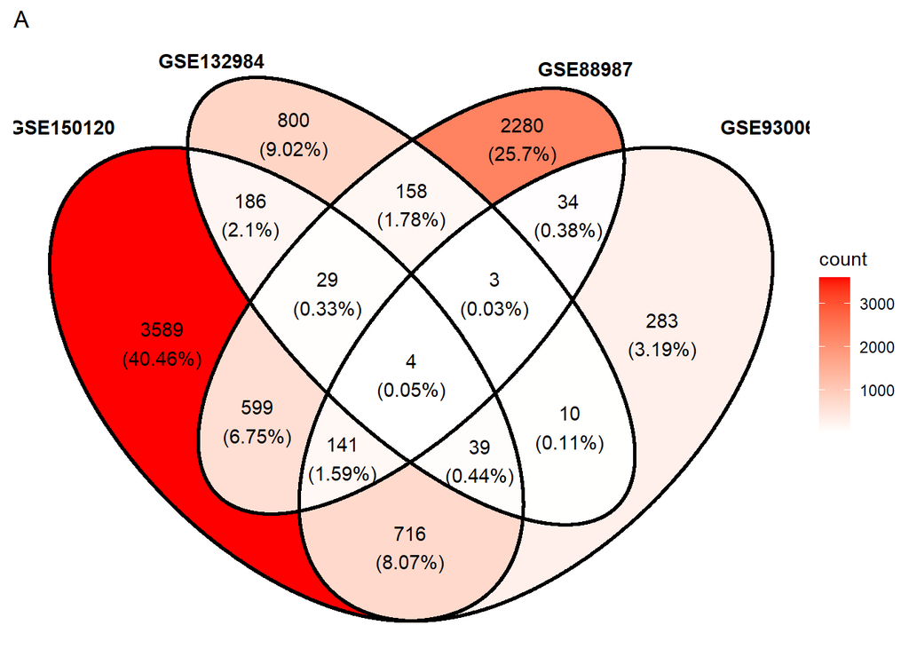

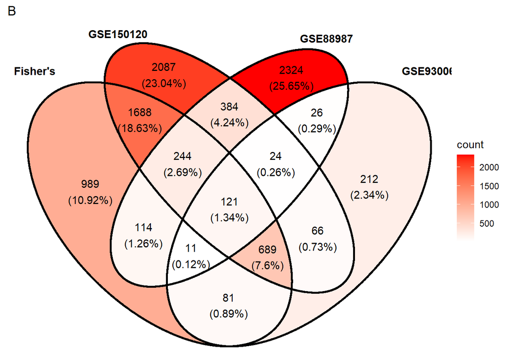

```r
library(ggVennDiagram)
library(ggplot2)

set.seed(20190708)


x0 <- list(
  B = sample(rownames(res[which(res$pvalue<0.05&res$log2FoldChange>0),])),
  C = sample(rownames(tox_result[which(tox_result$pvalue<0.05&tox_result$log2FoldChange>0),])),
   D = sample(rownames(data_result[which(data_result$pvalue<0.05&data_result$log2FoldChange>0),])),
  E = sample(rownames(comparison_result[which(comparison_result$pvalue<0.05&comparison_result$log2FoldChange>0),]))
  )


ggVennDiagram(x0, label_alpha = 0, category.names = c("GSE150120","GSE132984","GSE88987","GSE93006"),color="black",size=1)+ggtitle("A")


#For Upregulation
x1 <- list(
 A = sample(rownames((as.data.frame(Fisher$Upper[which(Fisher$Upper<0.05)])))),
  B = sample(rownames(res[which(res$pvalue<0.05&res$log2FoldChange>0),])),
   D = sample(rownames(data_result[which(data_result$pvalue<0.05&data_result$log2FoldChange>0),])),
 E = sample(rownames(comparison_result[which(comparison_result$pvalue<0.05&comparison_result$log2FoldChange>0),]))
  )



ggVennDiagram(x1, label_alpha =0, category.names = c("Fisher's","GSE150120","GSE88987","GSE93006"),color="black",size=1)+ggtitle("B")+scale_fill_gradient(low="white",high = "red")
```

**Figure 9.Venn Diagram of the significantly upregulated genes** A.Venn diagram showing the upregulated genes(LFC>0) and p-values below 0.05 in all the four datasets used in the meta analysis. There are 4 genes found matching in all four datasets. B.Venn diagram showing the upregulated genes and p-values below 0.05 in all datasets with Fisher’s test results from meta-analysis except the data from GSE132984 which includes the count data from Tox-/- mutant mice. 121 genes are found to be significantly upregulated in datasets GSE150120, GSE88987, GSE93006 and Fisher’s test results.

Figure 9.B shows the upregulated genes with a Venn diagram of individual datasets as well as the meta-analysis results (Fisher’s test). In the diagram, three datasets are used except the GSE132984 which is shown to contribute to the meta-analysis results less than the other datasets. 121 genes are found to be shared between the datasets GSE150120, GSE88987, and GSE93006 and meta-analysis results. If the dataset of GSE132984 is added, the number of genes in the intersection drops to 33, therefore, the analysis is shown with the more related datasets.

The next Venn diagram in Figure 10. shows the downregulated genes in each dataset including Fisher’s test and the number of same genes shared by each dataset. Compared to the upregulation, it has been found that 11 genes are significantly downregulated in all four datasets in Figure 10.A. These genes are “Trgv2”, “Zdhhc18”, “Scamp3”, “Asb6”, “Gas7”,“Tmem37”, “Tpt1”,“Rasgrp2”,“Sla2”,“Ptk2b” and “Socs1”. Compared to the common upregulated gene number in Figure 9.A, there are more downregulated genes shared by all four datasets.

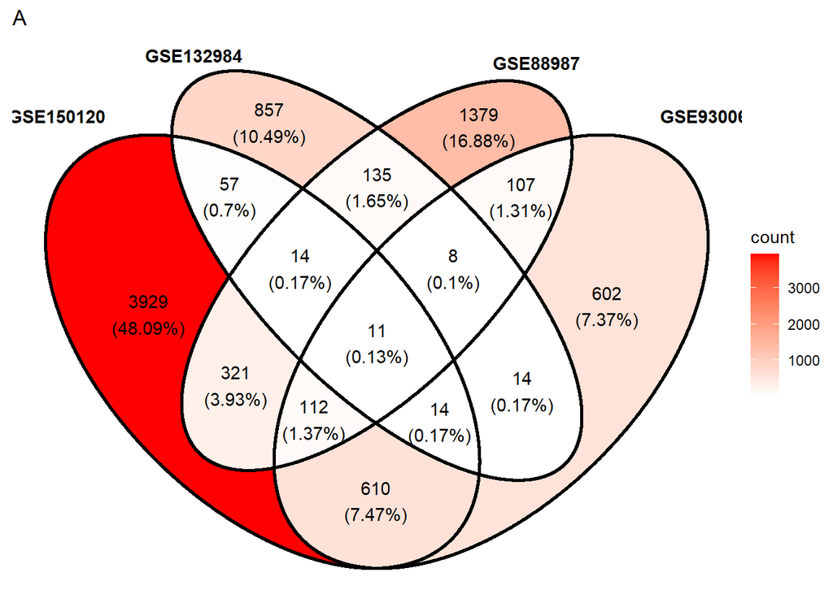

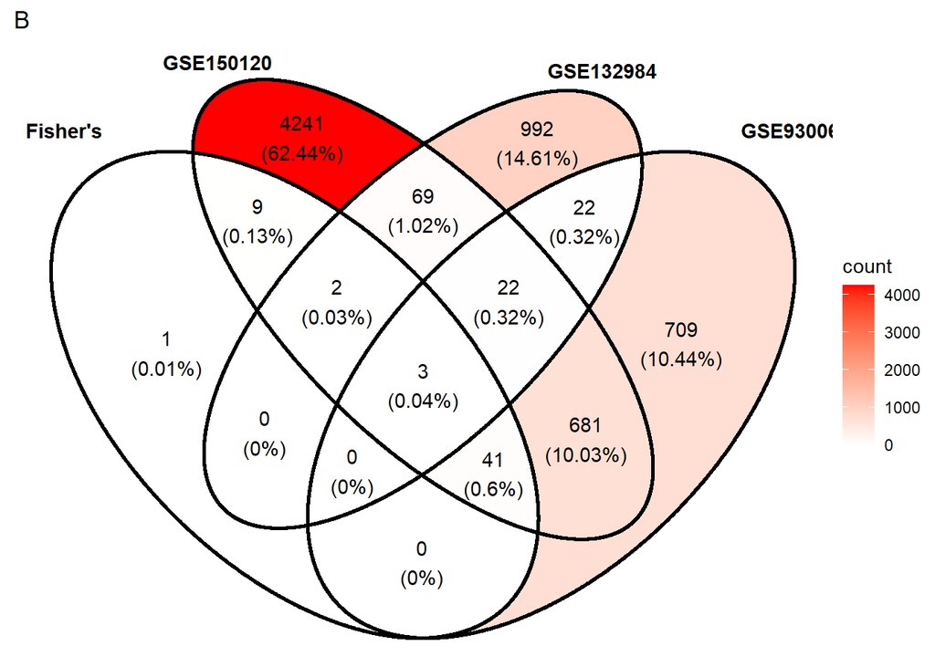

```r
#For down regulation

x3 <- list(
  B = sample(rownames(res[which(res$pvalue<0.05&res$log2FoldChange<0),])),
  C = sample(rownames(tox_result[which(tox_result$pvalue<0.05&tox_result$log2FoldChange<0),])),
   D = sample(rownames(data_result[which(data_result$pvalue<0.05&data_result$log2FoldChange<0),])),
  E = sample(rownames(comparison_result[which(comparison_result$pvalue<0.05&comparison_result$log2FoldChange<0),]))
  )

ggVennDiagram(x3, label_alpha = 0, category.names = c("GSE150120","GSE132984","GSE88987","GSE93006"),color="black",size=1)+ggtitle("A")


x2 <- list(
  A = sample(rownames((as.data.frame(Fisher$Lower[which(Fisher$Lower<0.05)])))),
  B = sample(rownames(res[which(res$pvalue<0.05&res$log2FoldChange<0),])),
  C = sample(rownames(tox_result[which(tox_result$pvalue<0.05&tox_result$log2FoldChange<0),])),
 E = sample(rownames(comparison_result[which(comparison_result$pvalue<0.05&comparison_result$log2FoldChange<0),]))
  )
ggVennDiagram(x2, label_alpha = 0,category.names = c("Fisher's","GSE150120","GSE132984","GSE93006"),color="black",size=1)+ggtitle("B")
```

**Figure 10.Venn Diagram of the significantly downregulated genes** A.Venn diagram showing the downregulated genes(LFC<0) and p-values below 0.05 in all the four datasets used in the meta analysis. B.Venn diagram showing the downregulated genes and p-values below 0.05 in all datasets with Fisher’s test results from meta-analysis except the data from GSE88987 unlike the Figure 10.B. This time inclusion of GSE88987 and the exclusion of GSE132984 results in 2 common genes while the excluding only GSE88987 dataset results in 3 common genes in the intersection of the diagrams. Therefore, 3 genes are found to be matching in all datasets including the Fisher’s test from meta-analysis.

The downregulated gene results from Fisher’s test are compared to each dataset in Figure 10.B. However, it has been found that there is no intersection or shared genes in all datasets and the meta-analysis results. Therefore, the dataset GSE88987 is excluded in the Venn diagram, and 3 genes are found to be shared between the three datasets and meta-analysis results. When GSE132984 is excluded like in the Venn diagram in Figure 9.B, there are 2 genes found to be shared by all of them. That’s why the GSE132984 dataset is involved in the downregulated gene analysis while the GSE88987 dataset is left out. The 3 shared genes with the meta-analysis results are “Aqp9”, “Emb” and “Tgfbr2”. Aqp9 gene encodes for aquaporin 9 which is a membrane protein that acts as a channel for water and small solutes. Its reduced expression is related to lower cytokine and chemokine secretion in exhausted CD8+ T cells since aquaporins 9 is reported to play a role in the inflammatory response.[8,18] Emb gene encodes an immunoglobulin superfamily transmembrane protein which might be involved in the development and cell growth.[9] Tgfbr2 gene encodes for transforming growth factor-beta receptor 2 that is known to regulate cell proliferation, cell cycle arrest, and immunosuppression.[10]

# Discussion

Exhaustion in CD8+ T cells is first examined in the separate studies starting with the study whose GEO accession number is GSE150120. Differentially expressed genes in this study are shown in Figures 1. and 2. When the repeatedly stimulated cells are compared to one-time stimulated cells, the Nod1 gene is appeared to be greatly decreased in expression. This confirms the experimental conditions of the study. The repeatedly stimulated cells represent exhausted CD8+ T cells while the one-time stimulated cells represent effector CD8+ T cells. Nod1 gene encodes for Nod1 protein which is a pattern recognition receptor for viral and bacterial pathogens and Nod1 protein is known to initiate inflammation and immune response. Moreover, the lacking of Nod1 receptors drives primed T cells into even cell death.[11] The decrease in Nod1 gene expression is due to the diminished capacity of exhausted cells to recognize pathogen-associated molecular patterns and their reduced effector capabilities. The heatmap in Figure 2. shows how the variance among genes in each T cell population differs. The genes showing a high variance in the exhausted, repeatedly stimulated, cells, do not show great variance in effector, one time stimulated, cells or naive, not stimulated, cells. However, the variance pattern in the effector and naive CD8+ T cells is observed to follow a similar pattern. Therefore, it could be elicited that the transcription profile of the exhaustion state is greatly different than the naive or effector T cell states.

Gene enrichment ontology analysis enables to obtain biological processes contributing to the exhaustion state in T cells rather than only genes. The gene ontology results from Table 1. and Figure 3. proves that the differentially expressed genes between the effector and exhausted CD8+ T cells contribute to the biological processes in exhaustion. The significant GO terms are related to T cell processes such as proliferation and differentiation. The acyclic graph reveals that the positive regulation of cell-cell adhesion, response to stress, cellular macromolecule biosynthetic process, and regulation of T cell activation are some of the significant biological processes to contribute to the analysis. Exhausted CD8+ T cells are mostly known for their expression of inhibitory receptors on their surfaces which is also observed in the gene ontology results as the positive regulation of cell-cell adhesion annotation contains some of the inhibitory receptors. The annotation of the stress response is also related to the exhaustion state in which T cells further might go into physical deletion.[12]

Meta-analysis is an important method to gather information from several studies and draw a conclusion from their combination. The meta-analysis provides a greater statistical significance compared to any of the individual studies since the analysis benefits from the larger number of samples and the variation among samples. Therefore, different RNA-seq results investigating the exhaustion state of CD8+ T cells are combined to create one large data pool which infers the true significant results. During the meta-analysis, p-value based methods, Fisher’s probability, and Stouffer’s Z-test are practiced. While Fisher’s probability is more sensitive to the low p-values, Stouffer’s test takes into account the weighting by the sample size. This difference is seen in the heatmaps in Figure 8. The genes that appeared to be significant in the heatmaps are involved in the exhaustion of CD8+ T cells as expected such as Gzmb which encodes for granzyme B found in cytotoxic T cells is highly expressed in exhausted CD8+ T cells.[13] However, some genes are not expected to be significant such as Maats1 which encodes cilia and flagella-associated protein and regulates motility during spermatogenesis.[14] Since the Maats1 gene does not play a role in the immune system or exhaustion of T cells, it could be regarded as an outlier.

One of the important results of the meta-analysis is the number of significantly upregulated and downregulated genes. The upregulated gene number is 70 times more than the downregulated gene number in Fisher’s test while this difference in number is decreased to 25 in Stouffer’test. The reason why there are so few downregulated genes might reflect the exhaustion state of CD8+ T cells. Because the exhaustion state is not a quiescent state where the CD8+ T cells remain inactive and transcriptionally silent but rather a lot of negative regulatory receptor is transcribed. And before the exhaustion state, T cells enter the memory state in which they remain quiescent.[15] The unbalance between the gene number could be explained by that or there could be other reasons for this unbalance such as the high heterogeneity and variance between studies or the usage of inappropriate studies or the inadequate data addition to meta-analysis.[16] These drawbacks could be overcome with the larger sample size and inclusion of more RNA-seq data.

Next, the meta-analysis results are compared to each RNA-seq data individually to depict the study’s role in the meta-analysis and observe the intersection between them. In the Venn diagrams in Figures 9. and 10., the meta-analysis results are compared with the results of the individual studies. While the DESeq2 method is used to determine differential gene expression in individual datasets, NOISeq is used in the meta-analysis due to its effectiveness against the bias that comes from read size effect. Because meta-analysis makes use of a variety of data with an uneven number of read size which causes the analysis to detect incorrect genes as differentially expressed. NOISeq eliminates this bias of read size effect between the studies. However, this could be some minor changes between the individual study analysis and meta-analysis since different methods like DESeq2 and NOISeq are used.

The Venn diagrams in Figure 9. point to the heterogeneity among the datasets. Because there are only 4 genes detected to be significantly upregulated by all four independent datasets. While this number is too low considering the thousand of upregulated genes in each dataset. This difference could be due to the dataset GSE132984 in which the CD8+ T cells are compared from wild-type mice and Tox knock-out mice. Tox is a known exhaustion marker in cytotoxic cells however, only knocking-out Tox could not reverse all the other exhaustion markers. Thus, we observe that the GSE132984 dataset does not share genes as much as with the other datasets. That’s why in the second Venn diagram in Figure 9.B, GSE132984 is excluded and the differential gene expression results of the other datasets are compared to meta-analysis. This diagram shows a higher number of shared genes between the datasets and meta-analysis which could be inferred as the heterogeneity comes from the GSE132984. However, this is not the case when the downregulated genes are compared. First of all, there are more genes are found to be downregulated in the intersection of the results of datasets. And when the datasets are compared with meta-analysis, this time GSE132984 datasets are observed to contribute to the diagram more, and all the datasets except GSE88987 and the meta-analysis share 3 significantly downregulated genes.

In conclusion, meta-analysis is highly crucial in high-throughput data analysis and very useful for determining significant genes that have an effect of exhaustion in CD8+ T cells. The addition of relevant experiments and their RNA-seq data could be combined to the meta-analysis to have a larger pool of samples and minimize the bias as long as the homogeneity is maintained among the studies. Combining more datasets to the meta-analysis could help to detect more exhaustion-related genes and inferring the transcriptional differences between cytotoxic T cell subsets.

# Methods

Statistics were done using R 4.0.0. In addition metaSeq(v3.10; Tsuyuzaki&Nikaido, 2019), DESeq2(v3.12; Love, 2014), ggplot2(v3.3.3; Wickham, 2020) and topGO(v3.12; Alexa, 2020) packages are used.

# Data Availability

The raw count datasets of the RNA-Seq results are provided with Gene Expression Omnibus (GEO). Accession numbers of the datasets used in the paper are GSE150120, GSE132984, GSE93006 and GSE88987.

# References

1.Kurachi, M. CD8+ T cell exhaustion. Semin Immunopathol 41, 327?337 (2019). https://doi.org/10.1007/s00281-019-00744-5

2.Haidich A. B. (2010). Meta-analysis in medical research. Hippokratia, 14(Suppl 1), 29?37.

3.Geddes, K., Magalh?es, J. & Girardin, S. Unleashing the therapeutic potential of NOD-like receptors. Nat Rev Drug Discov 8, 465?479 (2009). https://doi.org/10.1038/nrd2783

4.Love MI, Anders S, Kim V and Huber W. RNA-Seq workflow: gene-level exploratory analysis and differential expression.https://doi.org/10.12688/f1000research.7035.2

5.Love, M. I., Huber, W., & Anders, S. (2014). Moderated estimation of fold change and dispersion for RNA-seq data with DESeq2. Genome biology, 15(12), 550. https://doi.org/10.1186/s13059-014-0550-8

6.Heard, N. A., & Rubin-Delanchy, P. (2018). Choosing between methods of combining p-values. Biometrika, 105(1), 239-246. https://doi.org/10.1093/biomet/asx076

7.Chen, Z., Yang, W., Liu, Q. et al. A new statistical approach to combining p-values using gamma distribution and its application to genome-wide association study. BMC Bioinformatics 15, S3 (2014). https://doi.org/10.1186/1471-2105-15-S17-S3

8.Liu, X., Xu, Q., Li, Z., & Xiong, B. (2020). Integrated analysis identifies AQP9 correlates with immune infiltration and acts as a prognosticator in multiple cancers. Scientific reports, 10(1), 20795. https://doi.org/10.1038/s41598-020-77657-z

9.Chao, F., Zhang, J., Zhang, Y., Liu, H., Yang, C., Wang, J., Guo, Y., Wen, X., Zhang, K., Huang, B., Liu, D., & Li, Y. (2015). Embigin, regulated by HOXC8, plays a suppressive role in breast tumorigenesis. Oncotarget, 6(27), 23496?23509. https://doi.org/10.18632/oncotarget.4360

10.Oh, S. A., & Li, M. O. (2013). TGF-?: guardian of T cell function. Journal of immunology (Baltimore, Md. : 1950), 191(8), 3973?3979. https://doi.org/10.4049/jimmunol.1301843

11.Kasimsetty, S. G., Shigeoka, A. A., Scheinok, A. A., Gavin, A. L., Ulevitch, R. J., & McKay, D. B. (2017). Lack of Both Nucleotide-Binding Oligomerization Domain-Containing Proteins 1 and 2 Primes T Cells for Activation-Induced Cell Death. Journal of immunology (Baltimore, Md. : 1950), 199(3), 1196?1205. https://doi.org/10.4049/jimmunol.1600667

12.Jiang, Y., Li, Y. & Zhu, B. T-cell exhaustion in the tumor microenvironment. Cell Death Dis 6, e1792 (2015). https://doi.org/10.1038/cddis.2015.162

13.Verdon, D. J., Mulazzani, M., & Jenkins, M. R. (2020). Cellular and Molecular Mechanisms of CD8(+) T Cell Differentiation, Dysfunction and Exhaustion. Int J Mol Sci, 21(19). doi:10.3390/ijms21197357

14.Yukitake H, Furusawa M, Taira T, Iguchi-Ariga SM, Ariga H. AAT-1, a novel testis-specific AMY-1-binding protein, forms a quaternary complex with AMY-1, A-kinase anchor protein 84, and a regulatory subunit of cAMP-dependent protein kinase and is phosphorylated by its kinase. J Biol Chem. 2002 Nov 22;277(47):45480-92. doi: 10.1074/jbc.M206201200. Epub 2002 Sep 9. PMID: 12223483.

15.Kalia V, Penny LA, Yuzefpolskiy Y, Baumann FM, Sarkar S. Quiescence of Memory CD8(+) T Cells Is Mediated by Regulatory T Cells through Inhibitory Receptor CTLA-4. Immunity. 2015 Jun 16;42(6):1116-29. doi: 10.1016/j.immuni.2015.05.023. PMID: 26084026.

16.Tawfik, G.M., Dila, K.A.S., Mohamed, M.Y.F. et al. A step by step guide for conducting a systematic review and meta-analysis with simulation data. Trop Med Health 47, 46 (2019). https://doi.org/10.1186/s41182-019-0165-6

17.Introduction to SAS. UCLA: Statistical Consulting Group. from https://stats.idre.ucla.edu/sas/modules/sas-learning-moduleintroduction-to-the-features-of-sas/ (accessed August 22, 2016).

18.Tsuyuzaki K, Nikaido I (2020). metaSeq: Meta-analysis of RNA-Seq count data in multiple studies. R package version 1.30.0.